# Assignment 2: Voting Visualized

## Deadline

Oct. 24th

## Important notes

- Make sure you push on GitHub your notebook with all the cells already evaluated.
- Note that maps do not render in a standard Github environment. You should export them to HTML and link them in your notebook.
- Don't forget to add a textual description of your thought process, the assumptions you made, and the solution you implemented.
- Please write all your comments in English, and use meaningful variable names in your code.

## Background

- Are you curious to know what the political leanings of the people of Switzerland are?
- Do you wake up in a cold sweat, wondering which party won the last cantonal parliament election in Vaud?
- Are you looking to learn all sorts of visualizations, including maps, in Python?

If your answer to any of the above is yes, this assignment is just right for you. Otherwise, it's still an assignment, so we're terribly sorry.

The chief aim of this assignment is to familiarize you with visualizations in Python, particularly maps, and also to give you some insight into how visualizations are to be interpreted. The data we will use is the data on Swiss cantonal parliament elections from 2007 to 2018, which contains, for each cantonal election in this time period, the voting percentages for each party and canton.

For the visualization part, install Folium (*Hint: it is not available in your standard Anaconda environment, therefore search on the Web how to install it easily!*). Folium's README comes with very clear examples, and links to their own iPython Notebooks -- make good use of this information. For your own convenience, in this same directory you can already find one TopoJSON file, containing the geo-coordinates of the cantonal borders of Switzerland.

One last, general reminder: back up any hypotheses and claims with data, since this is an important aspect of the course.

```python
import folium
import pandas as pd
import numpy as np
import matplotlib.pyplot as plt
import json
import os

import ipywidgets as widgets
```

```python
#Import external files
data_folder = './data/'
cantons = pd.read_csv(data_folder + 'cantons.csv')
cantonsGeo = r'./data/ch-cantons.topojson.json'
pathgeo = os.path.join('./data', 'ch-cantons.topojson.json')
geojson = json.load(open(cantonsGeo))
```

```python
#Import and parse communes_pop.xls
#Import and skip 5 rows (titles and blank) et 7 footers rows
communes_pop = pd.read_excel(data_folder + 'communes_pop.xls',skiprows=5,skipfooter=7)
#Rename first column in Canton
communes_pop.rename(index=str, columns={"Unnamed: 0": "Canton"},inplace=True)
#Delete rows with Nan Canton name
communes_pop = communes_pop[communes_pop.Canton.notnull()]
#Keep canton name started with '-'
communes_pop = communes_pop[communes_pop.Canton.str.startswith(('-'))]



communes_pop.head()
```

|  | Canton | au 1er janvier | Unnamed: 2 | Unnamed: 3 | Unnamed: 4 | Unnamed: 5 | Unnamed: 6 | Unnamed: 7 |  | au 31 décembre | Unnamed: 10 | Unnamed: 11 |
| --- | --- | --- | --- | --- | --- | --- | --- | --- | --- | --- | --- | --- |
| 1 | - Zürich | 1487969 | 17070 | 11076 | 5994 | 120593 | 108666 | 11927 | -1544 | 1504346 | 16377 | 1.100628 |
| 182 | - Bern / Berne | 1026513 | 10141 | 9465 | 676 | 76763 | 72299 | 4464 | -527 | 1031126 | 4613 | 0.449385 |
| 544 | - Luzern | 403397 | 4384 | 3077 | 1307 | 30501 | 28994 | 1507 | 295 | 406506 | 3109 | 0.770705 |
| 634 | - Uri | 36145 | 350 | 359 | -9 | 2342 | 2166 | 176 | -13 | 36299 | 154 | 0.426062 |
| 655 | - Schwyz | 155863 | 1510 | 1067 | 443 | 11045 | 10095 | 950 | 45 | 157301 | 1438 | 0.922605 |

```python
#Import and parse national_council_elections.xlsx
#Skip the 4 firsts raws
national_council = pd.read_excel(data_folder + 'national_council_elections.xlsx',skiprows=4)
#Replace first column name by Canton
national_council.rename(index=str, columns={"Unnamed: 0": "Canton"},inplace=True)
#Replace the column name by Electeurs votant
national_council.rename(index=str, columns={"Electeurs 2)": "Electeurs votant"},inplace=True)
#Drop rows with more than 2 columns with Nan values
national_council = national_council.dropna(thresh=2)
#Drop the first row with total
national_council.drop(national_council.index[0], inplace=True)

national_council.head()
```

|  | Canton | Electeurs inscrits | Electeurs votant | Participation en % |
| --- | --- | --- | --- | --- |
| 4 | Zurich | 907623.0 | 428837.0 | 47.248362 |
| 5 | Berne | 729203.0 | 357770.0 | 49.063155 |
| 6 | Lucerne | 271143.0 | 138096.0 | 50.931059 |
| 7 | Uri 1) | 26414.0 | 15091.0 | 57.132581 |
| 8 | Schwytz | 102145.0 | 54857.0 | 53.705027 |

```python
#Choose the usefull columns into voters.xls
usefullColumns = {0,2,3,6,8,10,14,18,20,24,26,28,30,34,36,38,40,44,48,50,60}
#Import and keep the usefull columns
voters = pd.read_excel(data_folder + 'voters.xls',skiprows=3,usecols=usefullColumns)
#Rename the column by Canton
voters.rename(index=str, columns={"Unnamed: 0": "Canton"},inplace=True)
#Drop rows with more than 2 columns with Nan values
voters = voters.dropna(thresh=2)

voters.head()
```

|  | Canton | Année électorale 2) | Participation | PDC 7) | PS | UDC | PLS 6) | PEV | PCS | PVL | ... | PST 9) | PSA | PES | AVF 8) | Sol. | DS | UDF | Lega | MCR | Autres 11) |
| --- | --- | --- | --- | --- | --- | --- | --- | --- | --- | --- | --- | --- | --- | --- | --- | --- | --- | --- | --- | --- | --- |
| 2 | Zurich | 2015.0 | 32.652497 | 4.878712 | 19.716444 | 30.023215 | NaN | 4.271767 | NaN | 7.637858 | ... | NaN | NaN | 7.218776 | 2.977664 | NaN | NaN | 2.662277 | NaN | NaN | 0.669707 |
| 3 | Berne | 2018.0 | 30.516313 | 0.671415 | 22.328775 | 26.760869 | NaN | 6.172897 | NaN | 6.914731 | ... | 0.327589 | 0.681873 | 10.104467 | 0.495841 | NaN | 0.179432 | 3.710624 | NaN | NaN | 0.912781 |
| 4 | Lucerne | 2015.0 | 38.741267 | 30.862513 | 11.848915 | 24.115646 | NaN | 0.199143 | NaN | 4.320211 | ... | NaN | NaN | 6.700011 | NaN | NaN | NaN | NaN | NaN | NaN | 0.036129 |
| 5 | Uri 1) | 2016.0 | 61.989056 | 31.298814 | 12.984966 | 24.053191 | NaN | NaN | NaN | NaN | ... | NaN | NaN | 2.378061 | NaN | NaN | NaN | NaN | NaN | NaN | 2.428270 |
| 6 | Schwytz | 2016.0 | 37.747088 | 27.167707 | 12.925363 | 33.115090 | NaN | 0.304428 | NaN | 2.544623 | ... | NaN | NaN | 0.800215 | NaN | NaN | NaN | NaN | NaN | NaN | 1.513578 |

5 rows × 21 columns

## Task 1: Cartography and census

**A)** Display a Swiss map that has cantonal borders as well as the national borders. We provide a TopoJSON `data/ch-cantons.topojson.json` that contains the borders of the cantons.

**B)** Take the spreadsheet `data/communes_pop.xls`, collected from [admin.ch](https://www.bfs.admin.ch/bfs/fr/home/statistiques/catalogues-banques-donnees/tableaux.assetdetail.5886191.html), containing population figures for every commune. You can use [pd.read_excel()](https://pandas.pydata.org/pandas-docs/version/0.20/generated/pandas.read_excel.html) to read the file and to select specific sheets. Plot a histogram of the population counts and explain your observations. Do not use a log-scale plot for now. What does this histogram tell you about urban and rural communes in Switzerland? Are there any clear outliers on either side, and if so, which communes?

**C)** The figure below represents 4 types of histogram. At this stage, our distribution should look like Fig.(a). A common way to represent [power-laws](https://en.wikipedia.org/wiki/Power_law) is to use a histogram using a log-log scale -- remember: the x-axis of an histogram is segmented in bins of equal sizes and y-values are the average of each bin. As shown in Fig.(b), small bins sizes might introduce artifacts. Fig.(b) and Fig.(c) are examples of histograms with two different bin sizes. Another great way to visualize such distribution is to use a cumulative representation, as show in Fig.(d), in which the y-axis represents the number of data points with values greater than y.

Create the figures (b) and (d) using the data extracted for task 1B. For Fig.(b), represent two histograms using two different bin sizes and provide a brief description of the results. What does this tell you about the relationship between the two variables, namely the frequency of each bin and the value (i.e. population in case of the communal data) for each bin?

[figure not shown]

The figure is extracted from [this paper](https://arxiv.org/pdf/cond-mat/0412004.pdf) that contains more information about this family of distributions.

**A)** Display a Swiss map that has cantonal borders as well as the national borders. We provide a TopoJSON `data/ch-cantons.topojson.json` that contains the borders of the cantons.

#### Answer A

```python
switzerland = folium.Map(location=[46.8, 8.33],tiles='Mapbox Bright', zoom_start=7)

folium.TopoJson(
    open(pathgeo),
    'objects.cantons',
    name='topojson'
).add_to(switzerland)

switzerland.save("task1A.html")
switzerland
```

[interactive chart not shown]

Map related to this exercise : task1A.html

**B)** Take the spreadsheet `data/communes_pop.xls`, collected from [admin.ch](https://www.bfs.admin.ch/bfs/fr/home/statistiques/catalogues-banques-donnees/tableaux.assetdetail.5886191.html), containing population figures for every commune. You can use [pd.read_excel()](https://pandas.pydata.org/pandas-docs/version/0.20/generated/pandas.read_excel.html) to read the file and to select specific sheets. Plot a histogram of the population counts and explain your observations. Do not use a log-scale plot for now. What does this histogram tell you about urban and rural communes in Switzerland? Are there any clear outliers on either side, and if so, which communes?

#### Answer B

Let's have a look at the excel file containing the communes

```python
# load excel sheet
communes_pop_raw = pd.read_excel(data_folder + 'communes_pop.xls', \
                             sheet_name='2017')
communes_pop_raw.head(10)
```

|  | su-f-01.02.04.07 | Bilan de la population résidante permanente selon les districts et les communes, en 2017 | Unnamed: 2 | Unnamed: 3 | Unnamed: 4 | Unnamed: 5 | Unnamed: 6 | Unnamed: 7 | Unnamed: 8 | Unnamed: 9 | Unnamed: 10 | Unnamed: 11 |
| --- | --- | --- | --- | --- | --- | --- | --- | --- | --- | --- | --- | --- |
| 0 | NaN | NaN |  |  | NaN | NaN | NaN | NaN | NaN | NaN | NaN | NaN |
| 1 | NaN | NaN | Composantes de l'évolution de la population | NaN | NaN | NaN | NaN | NaN | NaN | NaN | Variation | NaN |
| 2 | NaN | Etat de la | Naissances | Décès | Accroissement | Arrivées 1) | Départs | Solde | Divergences | Etat de la | en nombres | en % |
| 3 | NaN | population | vivantes | NaN | naturel | NaN | NaN | migratoire 1) | statistiques | population | absolus | NaN |
| 4 | NaN | au 1er janvier | NaN | NaN | NaN | NaN | NaN | NaN |  | au 31 décembre | NaN | NaN |
| 5 | Suisse 2) | 8419550 | 87381 | 66971 | 20410 | 681011 | 635063 | 45948 | -1778 | 8484130 | 64580 | 0.767024 |
| 6 | - Zürich | 1487969 | 17070 | 11076 | 5994 | 120593 | 108666 | 11927 | -1544 | 1504346 | 16377 | 1.10063 |
| 7 | >> Bezirk Affoltern | 52904 | 517 | 310 | 207 | 4501 | 3862 | 639 | 21 | 53771 | 867 | 1.63882 |
| 8 | ......0001 Aeugst am Albis | 1977 | 10 | 7 | 3 | 129 | 165 | -36 | -3 | 1941 | -36 | -1.82094 |
| 9 | ......0002 Affoltern am Albis | 11900 | 128 | 93 | 35 | 1239 | 1029 | 210 | 1 | 12146 | 246 | 2.06723 |

So the first column contains names, the ninth the population (as of Dec 31st, 2017)  
We are only interested in communes, i.e. rows starting wit '......'. Furthermore we only care about total population, so we can omit the other columns

```python
# take communes and population of december columns, rename for convenience
communes = communes_pop_raw.iloc[:, [0, 9]]
communes.columns = ['commune', 'population']

# keep only communes, not cantons and districts
communes = communes[communes['commune'].str.contains('.....', regex=False, na=False)]
communes.head()
```

|  | commune | population |
| --- | --- | --- |
| 8 | ......0001 Aeugst am Albis | 1941 |
| 9 | ......0002 Affoltern am Albis | 12146 |
| 10 | ......0003 Bonstetten | 5512 |
| 11 | ......0004 Hausen am Albis | 3664 |
| 12 | ......0005 Hedingen | 3694 |

```python
# convert population column to numeric
communes['population'] = communes['population'].astype('int')
```

Let's plot a histogram of the population in communes

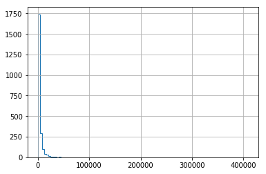

```python
communes['population'].hist(bins=100, histtype='step')
```

This histogram looks pretty distorted, we can smell outliers. It seems that there must be big sparse gaps. Further investigation:

```python
communes.describe()
```

|  | population |
| --- | --- |
| count | 2240.000000 |
| mean | 3787.558036 |
| std | 12436.473308 |
| min | 12.000000 |
| 25% | 679.000000 |
| 50% | 1493.500000 |
| 75% | 3643.500000 |
| max | 409241.000000 |

So at the 75% quantile there is a population 3643, but this is less than the mean of (rounded) 3787. The std deviation of over 12436 is very high compared to the mean.  
The maximum is a massive commune of over 400000 people. Let's take a look at the names of the 20 biggest communes

```python
top20 = communes.nlargest(20, 'population').reset_index()
top20
```

|  | index | commune | population |
| --- | --- | --- | --- |
| 0 | 186 | ......0261 Zürich | 409241 |
| 1 | 2326 | ......6621 Genève | 200548 |
| 2 | 998 | ......2701 Basel | 171513 |
| 3 | 1967 | ......5586 Lausanne | 138905 |
| 4 | 382 | ......0351 Bern | 133798 |
| 5 | 170 | ......0230 Winterthur | 110912 |
| 6 | 551 | ......1061 Luzern | 81401 |
| 7 | 1161 | ......3203 St. Gallen | 75522 |
| 8 | 1746 | ......5192 Lugano | 63494 |
| 9 | 230 | ......0371 Biel/Bienne | 54640 |
| 10 | 491 | ......0942 Thun | 43743 |
| 11 | 1681 | ......5002 Bellinzona | 43181 |
| 12 | 386 | ......0355 Köniz | 41507 |
| 13 | 2277 | ......6421 La Chaux-de-Fonds | 38625 |
| 14 | 811 | ......2196 Fribourg | 38521 |
| 15 | 1111 | ......2939 Schaffhausen | 36332 |
| 16 | 2348 | ......6643 Vernier | 35132 |
| 17 | 1305 | ......3901 Chur | 35038 |
| 18 | 2240 | ......6266 Sion | 34599 |
| 19 | 149 | ......0198 Uster | 34516 |

As you may have guessed, the outliers forming the top 10 are well-known swiss cities, topped by Zurich, Geneva, Basel, Lausanne and Bern.  
There is also a massive gap of over 200000 between Zurich and Geneva

```python
top20["population"][:5].agg('sum') / communes['population'].agg('sum')
```

```
0.12423253769095947
```

These 5 communes already make up for more than 12% of the swiss population, leaving the rest for the other 2235 communes  
Now we look, if there are especially small ones, let's say in the bottom 20

```python
bottom20 = communes.nsmallest(20, 'population').reset_index()
bottom20
```

|  | index | commune | population |
| --- | --- | --- | --- |
| 0 | 1706 | ......5102 Corippo | 12 |
| 1 | 959 | ......2549 Kammersrohr | 29 |
| 2 | 2196 | ......6172 Bister | 32 |
| 3 | 219 | ......0708 Schelten | 34 |
| 4 | 223 | ......0715 Rebévelier | 42 |
| 5 | 1362 | ......3707 Lohn (GR) | 42 |
| 6 | 319 | ......0972 Berken | 43 |
| 7 | 433 | ......0661 Clavaleyres | 46 |
| 8 | 1798 | ......5315 Linescio | 48 |
| 9 | 1796 | ......5309 Cerentino | 49 |
| 10 | 1794 | ......5304 Bosco/Gurin | 50 |
| 11 | 266 | ......0389 Meienried | 53 |
| 12 | 1363 | ......3708 Mathon | 53 |
| 13 | 1364 | ......3711 Rongellen | 53 |
| 14 | 1795 | ......5307 Campo (Vallemaggia) | 53 |
| 15 | 1360 | ......3703 Casti-Wergenstein | 55 |
| 16 | 2014 | ......5488 Mauraz | 60 |
| 17 | 1342 | ......3503 Mutten | 61 |
| 18 | 1833 | ......5684 Rossenges | 62 |
| 19 | 220 | ......0709 Seehof | 63 |

Again, we observe an outlier, a small commune named Corippo, with only 12 inhabitants, followed by Kammersrohr and Bister with already 29 and 32.

```python
n_communes_u300 = communes[communes['population'] < 300].size
n_communes_u300, n_communes_u300/communes.size
```

```
(394, 0.08794642857142858)
```

**C)** The figure below represents 4 types of histogram. At this stage, our distribution should look like Fig.(a). A common way to represent [power-laws](https://en.wikipedia.org/wiki/Power_law) is to use a histogram using a log-log scale -- remember: the x-axis of an histogram is segmented in bins of equal sizes and y-values are the average of each bin. As shown in Fig.(b), small bins sizes might introduce artifacts. Fig.(b) and Fig.(c) are examples of histograms with two different bin sizes. Another great way to visualize such distribution is to use a cumulative representation, as show in Fig.(d), in which the y-axis represents the number of data points with values greater than y.

Create the figures (b) and (d) using the data extracted for task 1B. For Fig.(b), represent two histograms using two different bin sizes and provide a brief description of the results. What does this tell you about the relationship between the two variables, namely the frequency of each bin and the value (i.e. population in case of the communal data) for each bin?

[figure not shown]

The figure is extracted from [this paper](https://arxiv.org/pdf/cond-mat/0412004.pdf) that contains more information about this family of distributions.

#### Answer C

So for Fig(b) we are plotting loglog histograms of the population, with two different bin numbers: 100 and 2000

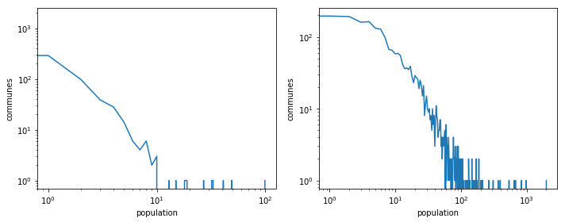

```python
populations = communes['population'].values

plt.figure(figsize=(10,4))

# plot loglog population hist with 100 bins on the left
plt.subplot(1,2,1)
plt.xlabel('population')
plt.ylabel('communes')
bins,_ = np.histogram(populations, bins=100)
plt.loglog(bins)

# plot loglog population hist with 2000 bins on the right
plt.subplot(1,2,2)
plt.xlabel('population')
plt.ylabel('communes')
bins,_ = np.histogram(populations, bins=2000)
plt.loglog(bins)

plt.tight_layout()
```

As we observe, these plots are similar to the given examples, suggesting that the distribution of communes sizes follows a power law.

At last we go for the cumulative visualization as in Fig(d), making it clearer and less noisy to see. We don't have a straight line on our loglog scales but it's not too far from it. So the power law might in a wider sense hold, although not being a perfect description of course, as there are always a lot of different factors and noises playing into such complex data.

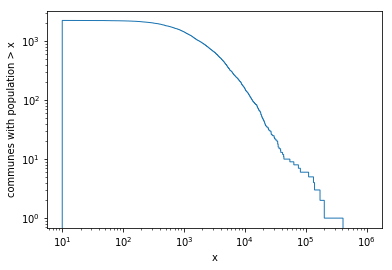

```python
plt.xlabel('x')
plt.ylabel('communes with population > x')
plt.xscale('log')
plt.yscale('log')

bins = np.logspace(1, 6, 2000)
plt.hist(populations, bins=bins, cumulative=-1, histtype='step')
plt.show()
```

## Task 2: Parties visualized

We provide a spreadsheet, `data/voters.xls`, (again) collected from [admin.ch](https://www.bfs.admin.ch/bfs/fr/home/statistiques/politique/elections/conseil-national/force-partis.assetdetail.217195.html), which contains the percentage of voters for each party and for each canton. For the following task, we will focus on the period 2014-2018 (the first page of the spreadsheet). Please report any assumptions you make regarding outliers, missing values, etc. Notice that data is missing for two cantons, namely Appenzell Ausserrhoden and Graubünden, and your visualisations should include data for every other canton.

For part B, you can use the `data/national_council_elections.xslx` file ([guess where we got it from](https://www.bfs.admin.ch/bfs/fr/home/statistiques/politique/elections/conseil-national/participation.assetdetail.81625.html)) to have the voting-eligible population of each canton in 2015.

**A)** For the period 2014-2018 and for each canton, visualize, on the map, **the percentage of voters** in that canton who voted for the party [`UDC`](https://en.wikipedia.org/wiki/Swiss_People%27s_Party) (Union démocratique du centre). Does this party seem to be more popular in the German-speaking part, the French-speaking part, or the Italian-speaking part?

```python
#Add Canton code into voters for merge it with JSON file
fit_canton = voters.set_index(cantons['Code'])
fit_canton['Code'] = fit_canton.index
#Keep interesting columns
fit_canton = fit_canton[['Canton','UDC','Code']]

m = folium.Map(location=[46.8, 8.33],tiles='Mapbox Bright', zoom_start=7)


m.choropleth(
    geo_data=geojson,
    data=fit_canton,
    columns=['Code', 'UDC'],
    topojson='objects.cantons',
    key_on='id',
    fill_color='BuPu',
    fill_opacity=0.7,
    line_opacity=0.5,
    legend_name='UDC vote (%)',
    threshold_scale=[0,25,50,75,100],
    reset=True
)

m.save("task2A.html")

m
```

[interactive chart not shown]

Map related to this exercise : task2A.html

**B)** For the same period, now visualize **the number of residents** in each canton who voted for UDC.

```python
#Add Canton code
population = communes_pop.set_index(cantons['Code'])
#Keep the right column
population = population[['au 1er janvier']]
#Rename it for better view
population.rename(index=str, columns={"au 1er janvier": "people"},inplace=True)
#Merge with UDC percent
final_tab = fit_canton.merge(population, on='Code')
#Filtered Nan UDC voting Canton
final_tab = final_tab[final_tab['UDC'].notnull()]


m = folium.Map(location=[46.8, 8.33],tiles='Mapbox Bright', zoom_start=7)


m.choropleth(
    geo_data=geojson,
    data=final_tab,
    columns=['Code', 'people'],
    topojson='objects.cantons',
    key_on='id',
    fill_color='BuPu',
    fill_opacity=0.7,
    line_opacity=0.5,
    legend_name='Number of residents',
    threshold_scale=[250000,500000,750000,1000000,1250000,1500000],
    reset=True
)

m.save("task2B.html")


m
```

[interactive chart not shown]

Map related to this exercise : task2B.html

**C)** Which one of the two visualizations above would be more informative in case of a national election with majority voting (i.e. when a party needs to have the largest number of citizens voting for it among all parties)? Which one is more informative for the cantonal parliament elections?

The more informative in case of national election is the second visualization. But for a cantonal parliament elections, tendencies shown in the first visualization are most important.

## Task 3: More socialism or more nationalism?

In this section, we focus on two parties that are representative of the left and the right on the Swiss political spectrum. You will propose a way to visualize their influence over time and for each canton.

**A)** Take the two parties [`UDC`](https://en.wikipedia.org/wiki/Swiss_People%27s_Party) (Union démocratique du centre) and [`PS`](https://en.wikipedia.org/wiki/Social_Democratic_Party_of_Switzerland) (Parti socialiste suisse). For each canton, we define 'right lean' in a certain period as follows:

$$\frac{VoteShare_{UDC} - VoteShare_{PS}}{VoteShare_{UDC} + VoteShare_{PS}}$$

Visualize the right lean of each canton on the map. What conclusions can you draw this time? Can you observe the [röstigraben](https://en.wikipedia.org/wiki/R%C3%B6stigraben) ?

```python
#A/

#Add canton code to voters
prepare_table = voters[['Canton','UDC','PS']]
prepare_table = prepare_table.set_index(cantons['Code'])
prepare_table['Code'] = prepare_table.index

#Add canton code to national_council
electors = national_council
electors = electors.set_index(cantons['Code'])
electors['Code'] = electors.index
electors


#Merge two DatFrame to obtain a final tab with Canton Code, UDC %, PS % and the number of electors in each canton
final = pd.merge(prepare_table, electors, on='Code')
final = final.dropna(thresh=2)
final = final[['Code','UDC','PS','Electeurs inscrits']]


#Number of people voting for UDC in each Canton
final["UDC"] = final["UDC"].multiply(final["Electeurs inscrits"], axis="index")
final["UDC"] = final['UDC'].apply(lambda x: x/100)

#Number of people voting for PS in each Canton
final["PS"] = final["PS"].multiply(final["Electeurs inscrits"], axis="index")
final["PS"] = final['PS'].apply(lambda x: x/100)





final['Right-Lean'] = (final.UDC - final.PS)/(final.UDC + final.PS)
final = final.dropna(thresh=3)

final.head()
```

|  | Code | UDC | PS | Electeurs inscrits | Right-Lean |
| --- | --- | --- | --- | --- | --- |
| 0 | ZH | 272497.603406 | 178950.977024 | 907623.0 | 0.207214 |
| 1 | BE | 195141.062082 | 162822.094999 | 729203.0 | 0.090286 |
| 2 | LU | 65387.886534 | 32127.504887 | 271143.0 | 0.341078 |
| 3 | UR | 6353.409773 | 3429.848997 | 26414.0 | 0.298833 |
| 4 | SZ | 33825.408663 | 13202.612222 | 102145.0 | 0.438521 |

```python
m = folium.Map(location=[46.8, 8.33],tiles='Mapbox Bright', zoom_start=7)

m.choropleth(
    geo_data=geojson,
    data=final,
    columns=['Code', 'Right-Lean'],
    topojson='objects.cantons',
    key_on='id',
    fill_color='BuPu',
    fill_opacity=0.7,
    line_opacity=0.5,
    legend_name='Right-Lean',
    threshold_scale=[-1,-0.5,0,0.5,1],
    reset=True
)

m.save("task3A.html")


m
```

[interactive chart not shown]

Map related to this exercise : task3A.htm

**B)** For each party, devise a way to visualize the difference between its 2014-2018 vote share (i.e. percentage) and its 2010-2013 vote share for each canton. Propose a way to visualize this evolution of the party over time, and justify your choices. There's no single correct answer, but you must reasonably explain your choices.

```python
from IPython.display import clear_output

dataVoters2014 = voters.set_index(cantons['Code'])
dataVoters2014['Code'] = dataVoters2014.index
dataVoters2014 = dataVoters2014.rename(columns={'PDC 7)': 'PDC', 'PLS 6)': 'PLS', 'PST 9)': 'PST', 'AVF 8)': 'AVF'})
dataVoters2014 = dataVoters2014.fillna(0)

usefullColumns = {0,2,3,6,8,10,14,18,20,24,26,28,30,34,36,38,40,44,48,50,60}
voters2010 = pd.read_excel(data_folder + 'voters.xls',skiprows=3,usecols=usefullColumns,sheet_name="2010-2013")
voters2010.rename(index=str, columns={"Unnamed: 0": "Canton"},inplace=True)
voters2010 = voters2010.dropna(thresh=2)

dataVoters2010 = voters2010.set_index(cantons['Code'])
dataVoters2010['Code'] = dataVoters2010.index
dataVoters2010 = dataVoters2010.rename(columns={'PDC 7)': 'PDC', 'PLS 6)': 'PLS', 'PST 9)': 'PST', 'AVF 8)': 'AVF'})
dataVoters2010 = dataVoters2010.fillna(0)

map2010 = folium.Map(location=[46.8, 8.33],tiles='Mapbox Bright', zoom_start=7)
map2010.choropleth(
    geo_data=geojson,
    data=dataVoters2010,
    columns=['Code', 'UDC'],
    topojson='objects.cantons',
    key_on='id',
    fill_color='BuPu',
    fill_opacity=0.7,
    line_opacity=0.5,
    legend_name='UDC vote (%) during 2010-2013',
    threshold_scale=[0,10,20,30,40,50],
    reset=True
)
map2014 = folium.Map(location=[46.8, 8.33],tiles='Mapbox Bright', zoom_start=7)
map2014.choropleth(
    geo_data=geojson,
    data=dataVoters2014,
    columns=['Code', 'UDC'],
    topojson='objects.cantons',
    key_on='id',
    fill_color='BuPu',
    fill_opacity=0.7,
    line_opacity=0.5,
    legend_name='UDC vote (%) during 2014-2018',
    threshold_scale=[0,10,20,30,40,50],
    reset=True
)



def on_button_clicked(b):
    party = b.description
    clear_output()
    map2010 = folium.Map(location=[46.8, 8.33],tiles='Mapbox Bright', zoom_start=7)
    map2010.choropleth(
        geo_data=geojson,
        data=dataVoters2010,
        columns=['Code', party],
        topojson='objects.cantons',
        key_on='id',
        fill_color='BuPu',
        fill_opacity=0.7,
        line_opacity=0.5,
        legend_name=party+' vote (%) during 2010-2013',
        threshold_scale=[0,10,20,30,40,50],
        reset=True
    )
    map2014 = folium.Map(location=[46.8, 8.33],tiles='Mapbox Bright', zoom_start=7)
    map2014.choropleth(
        geo_data=geojson,
        data=dataVoters2014,
        columns=['Code', party],
        topojson='objects.cantons',
        key_on='id',
        fill_color='BuPu',
        fill_opacity=0.7,
        line_opacity=0.5,
        legend_name=party+' vote (%) during 2014-2018',
        threshold_scale=[0,10,20,30,40,50],
        reset=True
    )
    display(widgets.HBox((PDC_bu,PS_bu,UDC_bu,PLS_bu,PEV_bu,PCS_bu,PVL_bu,PBD_bu,PSA_bu,PES_bu,AVF_bu,DS_bu,UDF_bu,Lega_bu)))
    map2010.save("task3B2010.html")
    map2010.save("task3B2014.html")
    display(map2010)
    display(map2014)

PDC_bu = widgets.Button(description="PDC")
PDC_bu.on_click(on_button_clicked)
PS_bu = widgets.Button(description="PS")
PS_bu.on_click(on_button_clicked)
UDC_bu = widgets.Button(description="UDC")
UDC_bu.on_click(on_button_clicked)
PLS_bu = widgets.Button(description="PLS")
PLS_bu.on_click(on_button_clicked)
PEV_bu = widgets.Button(description="PEV")
PEV_bu.on_click(on_button_clicked)
PCS_bu = widgets.Button(description="PCS")
PCS_bu.on_click(on_button_clicked)
PVL_bu = widgets.Button(description="PVL")
PVL_bu.on_click(on_button_clicked)
PBD_bu = widgets.Button(description="PBD")
PBD_bu.on_click(on_button_clicked)
PSA_bu = widgets.Button(description="PSA")
PSA_bu.on_click(on_button_clicked)
PES_bu = widgets.Button(description="PES")
PES_bu.on_click(on_button_clicked)
AVF_bu = widgets.Button(description="AVF")
AVF_bu.on_click(on_button_clicked)
DS_bu = widgets.Button(description="DS")
DS_bu.on_click(on_button_clicked)
UDF_bu = widgets.Button(description="UDF")
UDF_bu.on_click(on_button_clicked)
Lega_bu = widgets.Button(description="Lega")
Lega_bu.on_click(on_button_clicked)







display(widgets.HBox((PDC_bu,PS_bu,UDC_bu,PLS_bu,PEV_bu,PCS_bu,PVL_bu,PBD_bu,PSA_bu,PES_bu,AVF_bu,DS_bu,UDF_bu,Lega_bu)))
display(map2010)
display(map2014)
```

[interactive chart not shown]

One example only - execute code to access different buttons for party changing